# Final paper FAQs

## Do I need to include citations?

You aren’t required to include citations to any outside material. However, if you are using ideas or quotations from an outside source then you should cite that material. Any standard citation format (APA, MLA, Chicago) is fine as long as you’re consistent.

## What variables should I use?

This is (almost) entirely up to you! Remember that there’s a [detailed codebook](https://neilblund.github.io/GVPT201-Spring-2026/survey_codebook.html) on the course website that describes each variable and its values. As long as you can use a linear or logistic model for it, you can use it.

However, there are a few things you should probably consider when selecting variables:

1. **Variable types**: for a linear model, your dependent variable should be numeric or you should be able to treat it as numeric (5 or more ordered categories). Your independent variables can be numeric, ordinal or categorical.
2. **Interest and intuition**: you’re not necessarily being graded on the novelty of plausibility of your theory, but you’ll find its easier to write a paper if you can make an argument for *why* you think a relationship would exist between your selected variables.
3. **Conceptual/Operational definitions**: You should try to make your operational definition match your conceptual definition as closely as possible. You have *some* wiggle room here: you might use views on the Paris Climate accords as a rough proxy for people’s concern about climate change, but you would need to be open about the fact that this is only an indirect measure for the thing you’re theorizing about. On the other hand, you should avoid using an indirect measure if there’s a clearly better option available. For example: if your theory is all about party identification, you should probably use the variable that asks directly about party ID instead of a variable that asks about how feelings towards Trump.

## My results weren’t statistically significant! What should I do?

**You are not obligated to find statistically significant results. As long as you make a reasonable argument for why your hypothesis is worth testing, this is completely fine.**

If you do find that your hypothesis isn’t supported, you still need to interpret the coefficients, plot the results etc. and then acknowledge that your results don’t support your hypothesis. In the concluding section of the paper, you would also want to talk about why you think your hypothesis wasn’t supported. A few plausible reasons are:

- you’re wrong
- there’s not enough data
- there’s uncontrolled confounding[^1]
- sampling bias

You don’t need to give a definitive explanation, just show you’re thinking about your results and that you [understand what it means to reject or not reject the null hypothesis.](https://amstat.tandfonline.com/doi/full/10.1080/00031305.2016.1154108)

## How can I make sure my code is replicable?

Before submitting your R-code, its a good idea to double-check and make sure everything runs properly. The best way to do this is:

1. Restart R and clear the environment. To restart R, you can press Ctrl + Shift + F10, or just close and reopen R-Studio.
2. Clear the environment, just press the little broom 🧹 icon in the environment pane at the top right, or enter the following command into the console:

```r
rm(list = ls())
```

3. Run each line of code in your script, in order, [one line at a time](https://docs.posit.co/ide/user/ide/guide/code/execution.html#executing-a-single-line). Watch the console to make sure no error messages pop up and that you see your expected output.

## Can I use AI to write my paper or code?

You can use AI tools (ChatGPT, Claude, Gemini) to brainstorm or to proofread your paper. Under no circumstances should you submit code or writing that you didn’t write yourself.

## How should I format my plots and tables?

If you copy output directly from R into a word processor, you’ll end up with something that looks like this:

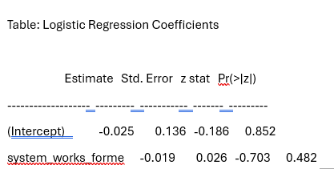

Avoid this! Copying output directly from the R console will usually give you very wonky text.

This is not great. Most word processors use variable width fonts. These are make prose text more readable, but they mess up the alignment in plots and tables. Instead of just copy-pasting the output, you either:

1. Create a table and enter the values yourself.
2. Use an R function to create formatted regression output.

Option 2 will probably be the easiest approach for most of you. Fortunately, you can get formatted output for most `RCPA3` functions by adding the `printC=TRUE` optional command to a function.

For instance, instead of running:

```r
# Running without printC

library(RCPA3)
model<-regC(carfatal ~ urban, data=states)
model
```

I would just add `printC=TRUE` as an additional argument:

```r
# Running the model with printC = TRUE
library(RCPA3)
model<-regC(carfatal ~ urban, data=states, printC=TRUE)
model
```

When you do this, you’ll see some text show up in the console that looks like:

```
Statement appended to Table.Output.Apr1126.html in C:/Users/neilb/Documents/UMD/GVPT201/GVPT201 Spring 2026
```

Go into the file location listed in this output and you should see a file called something like `Table.Output.Apr1126.html`. Click it and you should see formatted regression output. From here, you can actually just copy the coefficients table and paste it into a Word or Google doc, and it should come through looking fine.

**Alternatives to RCPA3**

If you’re comfortable working with R packages and syntax, there are lots of alternatives you could use to create formatted regression output. I personally like [modelsummary](https://modelsummary.com/vignettes/modelsummary.html).

## What is the most important stuff to tell readers?

Resist the temptation to write your analysis as a minute-by-minute account of everything you did to put the paper together. You should tell readers the things they need to know to **understand** your analysis; you don’t need to tell them everything you did to conduct your analysis.

For instance, here’s an example of extraneous detail:

Extraneous Detail

> My variable was initially called `paris_climate`, but I recoded it to a numeric variable and called it `paris_climate_numeric`

It’s important to tell readers when your treating ordinal variables as numeric, but they typically don’t need to know what a variable *used to be called* in R to interpret any part of your analysis. Instead, you can just say something like *“We asked respondents about whether they agreed or disagreed with the U.S. re-joining the Paris climate accords. Possible responses ranged from Strongly Disagree to Strongly Agree. For the analysis, these values were recoded to a 7-point numeric scale, with 1 indicating ‘strong disagreement’ and 7 indicating ‘strong agreement’*”

## Footnotes

[^1]: If you think there’s uncontrolled confounding and it comes from a variable that was measured on the survey, you might as well test it and say what you found! But it’s entirely possible that there’s some other confounding variable that wasn’t included in the data, in which case it’s fine to say “I suspect this matters, but I can’t test it with the available data”